# Efficient Frontier using R

This document presents the steps in plotting efficient frontier in R. GitHub repository is found [here](https://github.com/imjbmkz/efficient_frontier).

### Importing packages required

We will use several packages that will help us pull stocks data and to visualize simulated risks and returns. The following code installs the packages required if they’re not yet available. Afterwards, they will be loaded in our current R session.

```r
## (1) Define the packages that will be needed
packages <- c('quantmod', 'ggplot2', 'dplyr')

## (2) Install them if not yet installed
installed_packages <- packages %in% rownames(installed.packages())
if (any(installed_packages == FALSE)) {
  install.packages(packages[!installed_packages])
}

## (3) Load the packages into R session
invisible(lapply(packages, library, character.only = TRUE))
```

### Getting adjusted stock prices data

Let’s now load the stocks data that we will need. First, we will define a variable called `portfolio` that has the stock symbols that we want.

```r
## Create a character vector that has the stock codes we need
portfolio <- c('AUB', 'EW', 'PSB', 'PTC', 'UBP')
```

Then, let’s define the script that will load these stocks into R. We use `lapply` to “*apply*” a function across a list or a vector. The below code is going through all stock codes in `portfolio` variable, and loads it using the `getSymbols` function from quantmod package. Note that we are getting the weekly stocks data, and the parameter `auto.assign` is set to `FALSE` to load the `xts` object into `portfolio` variable. Finally, we give the list index names based on the data that they represent.

```r
## Load the stocks needed into R
portfolio <- lapply(portfolio, function(x) {getSymbols(
        x, periodicity='weekly', auto.assign=FALSE)})

## Set the names in the list to easily access them.
names(portfolio) <- c('AUB', 'EW', 'PSB', 'PTC', 'UBP')
```

We can look at the first few rows of the stocks data that we loaded.

```r
## View first three rows of selected stock
head(portfolio$AUB, 3)
```

```
##            AUB.Open AUB.High AUB.Low AUB.Close AUB.Volume AUB.Adjusted
## 2007-01-01    30.56    30.96   29.25     29.34      70200     19.40496
## 2007-01-08    29.50    29.90   28.40     29.90     109200     19.77532
## 2007-01-15    29.90    30.09   27.40     28.28      64700     18.70389
```

For this exercise, we are only interested in the adjusted prices of the stocks. The `Ad` function still from quantmod package does that. We again use `lapply` to use `Ad` function across all other stocks. To better work with the data, this has been transformed into an `xts` object instead of just a `list`.

```r
## Get adjusted prices of all stocks
portfolio_adjusted <- lapply(portfolio, Ad)

## Transform into xts
portfolio_adjusted <- do.call(merge, portfolio_adjusted)
```

Let’s see how the data looks like.

```r
## View first 3 rows of the combined different adjusted prices
head(portfolio_adjusted, 3)
```

```
##            AUB.Adjusted EW.Adjusted PSB.Adjusted PTC.Adjusted UBP.Adjusted
## 2007-01-01     19.40496    3.991667     41.46344        17.72     7.581705
## 2007-01-08     19.77532    4.106667     43.44649        17.94     7.966006
## 2007-01-15     18.70389    4.105000     44.37792        17.47     7.920873
```

### Getting weekly log returns

Now that we have our merged adjusted prices of different stock codes, let’s get their corresponding weekly returns. We still use `lapply`, `do.call`, and `merge` functions to do it. We are removing the first row since there are no returns on the first observation in the data.

```r
## Make a list that contains log weekly returns of each stock
portfolio_adjusted <- lapply(portfolio_adjusted, weeklyReturn, type='log')

## Transform into an xts object
portfolio_adjusted <- do.call(merge, portfolio_adjusted)

## Adjust the column names
colnames(portfolio_adjusted) <- c('AUB', 'EW', 'PSB', 'PTC', 'UBP')

## Remove first row since these do not have returns
portfolio_adjusted <- portfolio_adjusted[-1]
```

Let’s look at it.

```r
head(portfolio_adjusted, 3)
```

```
##                    AUB            EW        PSB         PTC          UBP
## 2007-01-08  0.01890635  0.0284028125 0.04671783  0.01233902  0.049445130
## 2007-01-15 -0.05570359 -0.0004060077 0.02121201 -0.02654785 -0.005681811
## 2007-01-22 -0.01066505  0.0351053984 0.01344955  0.12620646  0.009074865
```

#### Calculating return and risk statistics

```r
## Generate variance-covariance matrix
varCovMat <- var(portfolio_adjusted)

## Let's print it
varCovMat
```

```
##              AUB           EW          PSB          PTC          UBP
## AUB 0.0031628588 0.0004422811 0.0010578272 0.0012479309 0.0013298250
## EW  0.0004422811 0.0017959257 0.0005116239 0.0007158724 0.0005580336
## PSB 0.0010578272 0.0005116239 0.0014206380 0.0008829832 0.0010933121
## PTC 0.0012479309 0.0007158724 0.0008829832 0.0024499330 0.0009970158
## UBP 0.0013298250 0.0005580336 0.0010933121 0.0009970158 0.0024939910
```

We then need to turn it into annum variance-covariance. We do this by simply multiplying it by 52. It is 52 because our data is on a weekly scale (52 represents 52 weeks).

```r
## Multiply by 52 to get annum var-cov in weekly scale
varCovMat <- varCovMat * 52

## Print results
varCovMat
```

```
##            AUB         EW        PSB        PTC        UBP
## AUB 0.16446866 0.02299862 0.05500701 0.06489241 0.06915090
## EW  0.02299862 0.09338814 0.02660444 0.03722536 0.02901775
## PSB 0.05500701 0.02660444 0.07387318 0.04591513 0.05685223
## PTC 0.06489241 0.03722536 0.04591513 0.12739652 0.05184482
## UBP 0.06915090 0.02901775 0.05685223 0.05184482 0.12968753
```

#### Defining random weight combinations

We will define 10,000 combinations of random weights that we will use for each asset that we have. Using these weights, we will generate portfolio risks and returns for simulation purposes. We will set the seed to ensure that we get the same results every time we run these scripts.

```r
## Set seed for reproducibility
set.seed(42)

## Generate 50,000 random numbers
rand_weights <- runif(50000)

## Transform it into a matrix; each row will be a combination of weights
rand_weights <- matrix(rand_weights, nrow=10000, ncol=5)

## Add sixth column with just NAs
rand_weights <- cbind(rand_weights, rep(NA, 10000))

## Add names
colnames(rand_weights) <- c('AUB', 'EW', 'PSB', 'PTC', 'UBP', 'total')

## Loop to convert into actual weights
for (i in 1:10000) {
        rand_weights[i, 6] <- sum(rand_weights[i, 1:5])
        rand_weights[i, 1:5] <-
                rand_weights[i, 1:5] / rand_weights[i, 6]
}

## Delete total column
rand_weights <- rand_weights[, -6]
```

$$P_{Rt} = \sum P_w * P_{Cov}$$

Where, $P_Rt$ is our portfolio return, $P_w$ are the asset weights, then $P_{Cov}$ is the individual covariance per variable. We get $P_Rt$ by getting the sum of the product of weights and covariance.

Let’s code these in R.

```r
## Create column placeholders
portfolio_risk <- rep(NA, 10000)
portfolio_returns <- rep(NA, 10000)

## loop to calculate risk and return per weights
for (i in 1:10000) {
        weights <- rand_weights[i, ]
        portfolio_risk[i] <- sqrt(sum((weights %*% varCovMat) * weights))
        portfolio_returns[i] <- sum(weights * varCovMat[1, ])
}

## Make a data frame to be used for ggplot2
portfolio_df <- data.frame(portfolio_risk, portfolio_returns)
```

We already have the simulated risks and returns based from the randomized weights that we’ve generated. Using ggplot2 package, we can now plot this graph.

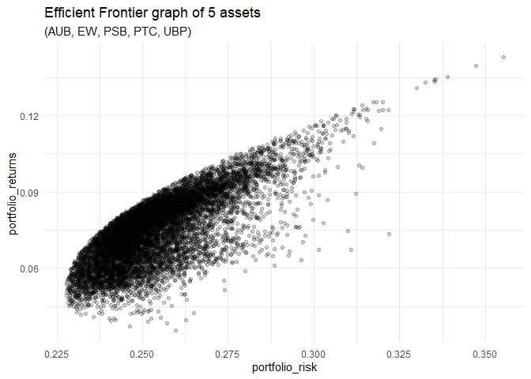

```r
portfolio_df %>%
        ggplot(aes(x=portfolio_risk, y=portfolio_returns)) +
        geom_point(alpha=0.2) +
        theme_minimal() +
        labs(
                title='Efficient Frontier graph of 5 assets',
                subtitle='(AUB, EW, PSB, PTC, UBP)')
```